# Predicting Operational Efficiency Using Cost Metrics in the Airline Industry

Group 3

18/11/2021

## Introduction

Commercial airlines constantly fight with high costs; even in the COVID year 2020 in which airlines were not flying at full capacity, the global costs of commercial airlines amounted to as much as 484 billion dollars (Iata, 2021). Especially in such difficult years, in which most airlines have lower than expected revenues with stable and high fix costs, airlines fight for survival. When commercial airlines struggle, one solution which quickly comes to mind is the potential improvement of their operational efficiency (i.e. the ratio of operating costs and revenue). Following this logic, airlines have already found numerous ways to improve operational efficiency, such as improving crew utilization, increasing payload on flights, or lowering fuel consumption; but there need to be new ways found to increase the likelihood of survival on this highly competitive market. Continuing this train of thought, we would like to introduce new ways to further improve commercial airlines efficiency through the use of machine learning based cost efficiency predictions.

In particular, the aim of this research was to predict operational efficiency of an airline using key cost metrics (e.g. load factor, fuel price) as predictors. These predictions are very valuable for airlines as they can become important key primary indicators (KPIs) to inform management about future company performance as well as the overall health of the industry. In this way, they provide an important instrument to base strategic company choices on sound, data based predictions instead of relying on solely traditional KPI’s such as profit or cost averages.

To improve model predictions beyond the quality of usual regression models, our research used kernel ridge regression (KRR) which incorporates non-linear relationships between the predicted variable and its predictors into its structure, making the predictions even more flexible.

This paper first explores the data used for predictions. Then, the choice for the KRR as well as its four different kernels is outlined and justified. Next, results provide an insight into the quality of the different kernels and the main KRR model. Finally, the paper concludes with a discussion on the findings and the different implications of those.

## Data

The dataset, obtained through Greene (2003), contains empirical evidence relating to the cost of the airline industry. It consists of a panel of 6 observations of Airlines in the United States over 15 years- from 1970 to 1984, yielding 90 observations in total. Data was collected for all six firms in the same fifteen years.

Each observation consists of six variables relating to an airline and its costs: airline name (airline), financial year (year), fuel price (pf), average capacity utilization of the airline’s fleet (i.e., load factor; lf), airline revenue per passenger-mile flown (output), total cost in $1000 (cost). Variable types differ between variables; fuel price, load factor, output, year, and cost are numeric variables while airline is treated as an categorical variable. As we are mostly interested in predicting operational efficiency of airlines for future years, we control for the year of observation, treating it as a continuous variable (for more information, see summary statistics in Table 1).

All observations are used for the study. As our approach relies on similar distributions and scales of our independent variables, all numeric independent variables are scaled to z-scores $(X – \mu) / \sigma$ where $\mu$ and $\sigma$ represent the mean and the standard deviation, respectively. This also that variables can be compared to each other.

| Variable | N | $\mu$ | SD | Mininimum | 25% | 50% | 75% | Maximum |
| --- | --- | --- | --- | --- | --- | --- | --- | --- |
| Revenue per Passenger-Mile Flown (in USD) | 90 | 0.5 | 0.5 | 0.0 | 0.1 | 0.3 | 1.0 | 1.9 |
| Total Cost (in million USD) | 90 | 1123 | 1192 | 69 | 292 | 637 | 1346 | 4748 |
| Fuel Price | 90 | 472 | 330 | 104 | 130 | 357 | 850 | 1016 |
| Load Factor | 90 | 56.0% | 5.3% | 43.2% | 52.9% | 56.6% | 59.5% | 67.6% |

Table 1: Summary Statistics of the data used (SD: Standard deviation)

## Methodology

In order to increase the prediction quality of our model, we move beyond the standard linear regression model. To increase model flexibility (i.e., to find a balance between variance and bias of predictions), we use basis expansion models (kernels). These models are popular in machine learning for their ability to extract more predictive information from provided datasets. In particular, kernels are used as a method that allows the introduction of non-linear components to linear regression, thus maintaining the convenience and ability of linear methods to not overfit. Kernels do so by embedding the points of any space into a new space where linearity can be applied via a non-linear feature map. The embedding computation is not made directly but through the kernel functions, built to be equivalent to the scalar products of the transformation (Hastie, Tibshirani, Friedman, 2008). In the analysis, linear kernels, polynomial kernels, radial basis function kernels and polyharmonic spline kernels are used.

Specifically, let $X \rightarrow R$ be the space that contains the data points $x_1,...,x_n \in X$, and $\Phi: X \rightarrow R^d$ a feature map where $\Phi$ denotes the $n \times d$ matrix containing data points $\Phi(x_i)$ as rows. Then, a symmetric function $k: X \times X \rightarrow R^d$ is a kernel function if for all $n \geq 1$ in $X$ and $c_1,...,c_n \in R^d$, it holds that:

$$\begin{equation} \label{eq:1}
\sum^n_{i,j = 1} c_ic_jk(x_i,x_j) \geq 0.
\end{equation}$$

The kernel function $k$ must be a symmetric and positive semi-definite function. The kernel function has a corresponding kernel matrix $k$ with entries $k_{ij}=k(x_i,x_j)$. By definition, a valid kernel matrix coincides with matrix $\Phi \cdot \Phi^T \in R^d$, having entries:

$$\begin{equation} \label{eq:2}
k_{ij} = \space <\Phi(x_i) , \Phi(x_j)> \space = \Phi(x_i) \Phi(x_j)^T \text{ for all } x,y \text{ in } X.
\end{equation}$$

Given $X$ and $k$, $\mathcal{H}$ denotes a Hilbert space with scalar product $< \cdot , \cdot >_{\mathcal{H}}$. The Reproducing Kernel Hilbert Space (RKHS) is the vector space $\mathcal{H}$ in which equality (2) holds.

The aim of the kernel method is to solve the general regression problem as a problem of finding the function $f$ that minimizes:

$$\begin{equation} \label{eq:3}
\mathop{min H[f]}_{f \in \mathcal{H}} = \frac{1}{n} \sum^n_{i=1} (y_i - f(x_i)) + \lambda ||f||^2_K,
\end{equation}$$

where $||f||^2_K$ is a norm in the RKFH $\mathcal{H}$ defined by the positive definite function $K$, $n$ is the number of data points and $\lambda$ is the regularization parameter (Evgeniou, Pontil, & Poggio, 1999, p. 2). The term $\lambda ||f||^2_K$ is built as a quadratic penalty factor based on the Ridge regression, which imposes the penalty on the size of the regression coefficients. This reduces the high dimensionality and high correlation of the regressors, that are problematic for conventional techniques such as the Ordinary Least Square optimization.

The introduction of kernels to the optimization problem (3) allows us to solve it purely in terms of kernel functions:

$$\begin{equation} \label{eq:4}
\mathop{maximize}_{\alpha \in R^n} \sum^n_{i=i} \alpha_i - \frac{1}{2} \sum^n_{i,j=1} \alpha_i \alpha_j y_i y_j K(x_i,x_j), \\
\end{equation}$$

subject to:
$$0 \leq \alpha_i \leq \frac{c}{n} \space \space \forall_i=1,...,n ,$$
$$\sum^n_{i=i} \alpha_i Y_i = 0.$$

The solution to the optimization problem can be found with the function $k$, ($X \times X$) with $k(x_i,y_i)=<\Phi(x_i),\Phi(x_j)>$.

Kernels not only allow us to find the minimization function, but are able to do so in a finite-dimensional subspace even though its respective RKHS is an infinite dimensional vector space (Vapnik, 1995). This is because $\mathcal{H}$ can be subdivided in $\mathcal{H}_{data}$, the $span$ {$k_{xi},...,k_{xn}$}, and $\mathcal{H}_{comp}$, its orthogonal complement. Each vector $w \in \mathcal{H}$ is $w = w_{data} + w_{comp}$. The prediction of all functions with the same $w_{data}$ agree on all training points, and as such is not affected by $w_{comp}$. As such, the norm $w$ is smallest if $w_{comp}=0$, thus always being an optimal solution. In this way, kernels allows us to combat the computational difficulties related to very large number of parameters.

In this analysis, four kernels are computed: the linear kernel (same as linear model), radial basis function (RBF) kernel, the inhomogeneous polynomial kernel (IPK), and the polyhomogeneous spline kernel (PSK). Different kernels are used to compare their ability to predict the data. Their functions are:

$$\begin{equation} \label{eq:5}
\text{ RBF: }k_{ii'}= e^{(-\gamma||x_i-x_i'||^2)}\text{, with hyperparameter} \gamma>0.
\end{equation}$$

$$\begin{equation} \label{eq:6}
\text{ IPK: }k_{ii'} = (1 + x_i^Tx_i')^d, \text{ with fixed degree} d>0.
\end{equation}$$

$$\begin{equation} \label{eq:7}
\text{PSK:\\}k_{ii'} = r^d, \text{ if } d=1,3,5,...,
\end{equation}$$

$$k_{ii'} = r^dln(r), \text{ if } d=2,4,6,...\text{ .}$$
Intuitively, RBF captures the similarity at point $y$ to a fixed point $x$ as a function of their distance. IPK considers combinations of the features of input samples (interaction features) to determine similarity.

Before conducting any in-depth analysis of the model, data was split into a training/validation dataset (first 12 years of data) and a testset (3 most recent years of data). Best models were first found using gridsearch and cross-validation on the training/validation dataset; the best models were then again trained on the training dataset and finally tested on the holdout testset.

Gridsearch was performed to find the best model hyperparameters. The search space of the gridsearch included a KRR parameter (i.e., $\lambda$) and different hyperparameters to define the kernel function (depended on the model). To find the best kernel/parameter combination, a 12-fold cross-validation was conducted for each parameter combination. Contrary to usual n-fold cross-validation, we defined the validation datasets based on year, with only entries in the validation dataset which belonged to the respective year. This way, we defined 11 validation splits (one between each year), which resulted in 12 validation datasets (one per year), hence 12-fold cross-validation. Using the optimal parameters from the gridsearch, the models were again trained on the whole training data set and evaluated using the test dataset.

In both the cross-validation and the test set our predictions were tested using the mean-squared prediction error ($MSPE$). $MSPE= \frac{1}{n}\sum^{n+q}_{i=n}(y_{i} - \hat{y}_{i})^{2}$, where $y_{i}$ is an output variable, and $\hat{y}_{i}$ is the predicted value over that period. In this example, $n$ is the number of observations in the training set, $q$ the number of observations in the test set. In each case a lower MSPE will be considered better predictive performance.

## Results

The four kernels produced a holistic picture of the possibilities of kernel based models and KRR in particular. This allowed us to make an informed decision on which kernels should be used in order to predict operational efficiency of airlines.

| Kernel type | CV-MSPE | Test-MSPE | $\lambda$ | Hyperparameter |  |  |
| --- | --- | --- | --- | --- | --- | --- |
| Linear | 0.0026 | 0.008 | 0.100 | - |  |  |
| Inhomogeneous | 0.0009 | 0.009 | 1.000 | 2.00 |  |  |
| Polyspline | 0.0012 | 0.152 | 1.000 | 2.00 |  |  |
| RBF | 0.0005 | 0.003 | 0.001 | 0.05 |  |  |

Table 2: Model Fits (CV-MSE: Cross-validation Mean Squared Error, MSPE: Mean Squared Prediction Error.)

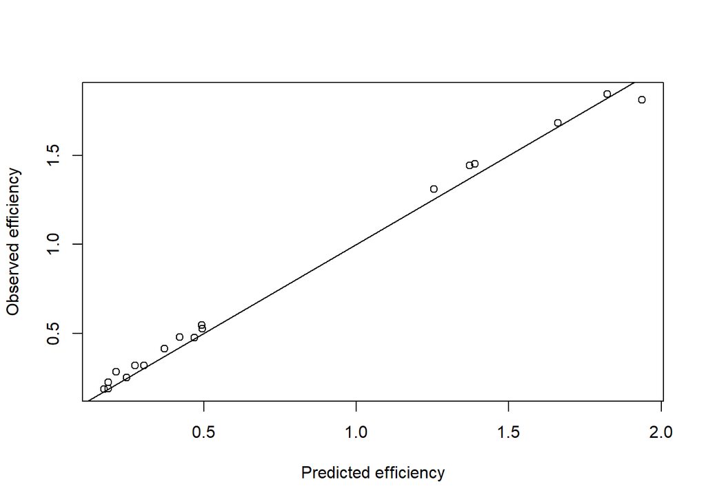

Observed efficiency vs. predicted efficiency by best model

```
## integer(0)
```

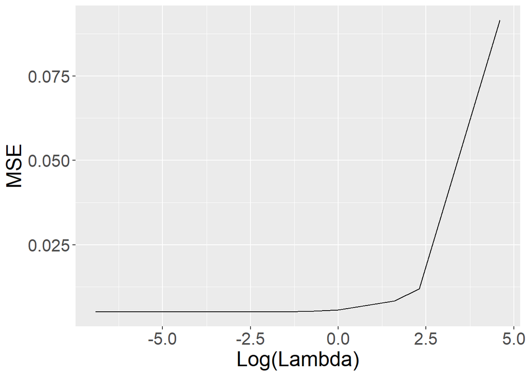

KRR with linear kernel: Impact of the choice of lambda parameter on the CV-MSPE

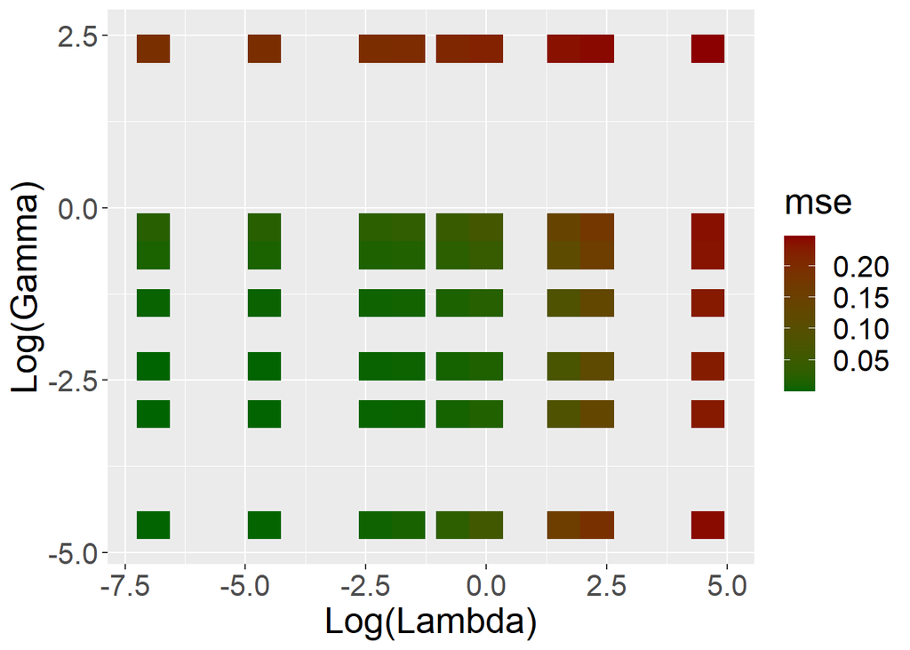

KRR with RBF kernel: CV-MSPE for different combinations of lambda and gamma

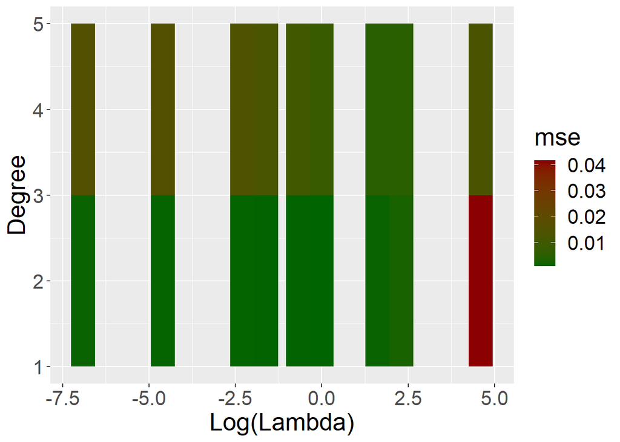

KRR with inhomogeneous kernel: CV-MSPE for different combinations of lambda and d

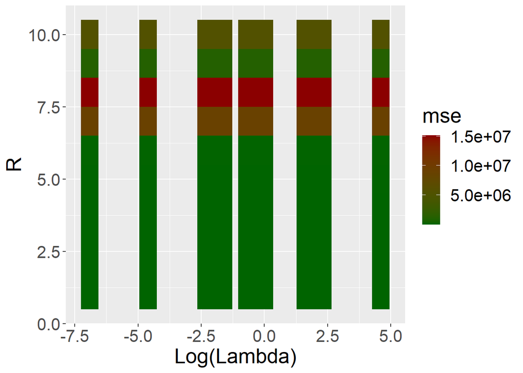

KRR with polynomial spline kernel: CV-MSPE for different combinations of lambda and r

The results indicate a superior performance of the linear kernel KRR over the performance the linear implementation of the OLS regression $MSPE_{OLS} = 0.572, MSPE_{KRR_{Linear}} = 0.008$.